# AFM

Paterne Stephane KOFFI

2023-06-08

# Analyse factorielle multiple (AFM)

Jusqu’ici nous avons étudié différentes techniques pour explorer des données multivariées soit quantitatives (ACP), soit qualitatives (AFC). Nous n’avons pas abordé encore la question de données mixtes avec des tableaux qui contiennent à la fois des variables quantitatives et des données qualitatives.

Une première approche consiste à convertir des variables afin d’homogénéiser le tableau. La conversion ne peut se faire qu’en dégradant l’information, soit dans le sens quantitatif continu -> quantitatif discret -> qualitatif ordonné -> qualitatif non ordonné -> binaire. Ainsi, dans un tableau contenant quelques variables quantitatives, nous pouvons créer des classes pour convertir les variables quantitatives en qualitatives. C’est par exemple ce que nous faisons quand nous remplaçons les indices de masse corporelle IMC dans nos données de biométrie humaine (quantitatif) en classes (tableau des classes proposées par l’OMS).

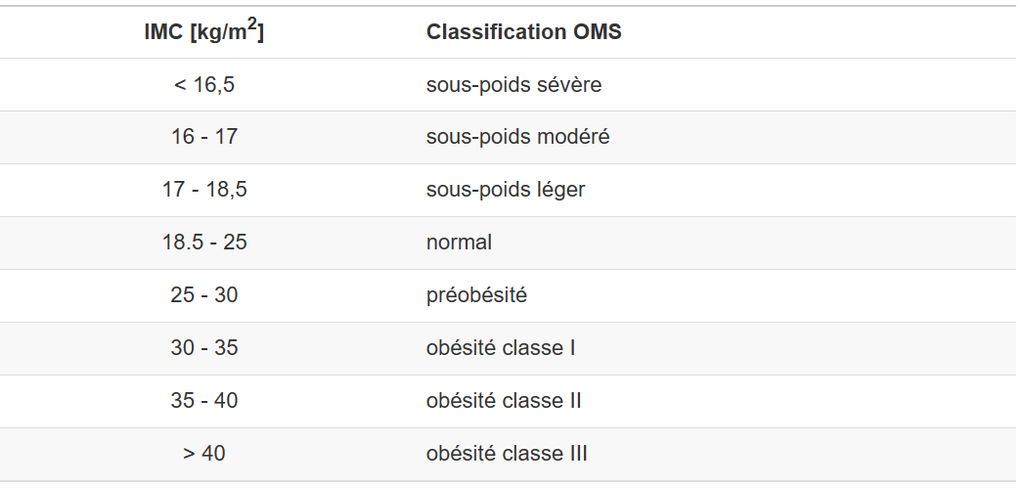

A l’extrême, il est toujours possible d’encoder n’importe quelle variable sous forme binaire. C’est ce qu’on appelle le codage disjonctif complet. Cette approche a non seulement l’avantage de transformer des variables différentes en 0 ou 1 dans un tableau homogène, mais permet aussi de comparer plus de deux variables qualitatives selon une extension de l’AFC dit Analyse en Composantes Multiples ou ACM que nous ne verrons pas dans ce cours, mais qu’il est important de mentionner pour mémo ici.

L’analyse factorielle multiple (AFM, multiple factorial analysis ou MFA en anglais) va permettre d’analyser simultanément plusieurs tableaux de données multivariés, et éventuellement mélanger des tableaux quantitatifs et qualitatifs (pour autant que les variables soient homogènes au sein de chaque tableau).

## AFM dans SciViews::R

Lorsque vous chargez les packages nécessaires à l’analyse exploratoire dans SciViews R à l’aide de SciViews::R(“explore”), vous avez à disposition la fonction mfa(data = …., formula) qui fera les calculs qui nous intéressent. Ensuite nous utiliserons summary() et chart$type() pour les graphiques, où type pourra être screeplot, altscreeplot, loadings, scores, groups, axes, frequences ou ellipses (nous verrons plus loin ce que représentent tous ces graphiques).

Nous allons aborder cette technique puissante, mais un peu plus complexe qu’est l’AFM sur la base d’un jeu de données que nous connaissons bien maintenant via nos exercices précédents : la communauté de plancton le long d’un transect entre Nice et la Corse.

## Plancton en Méditerranée

Les jeux de données marphy et marbio dans le package {pastecs} présentent deux tableaux de données complémentaires. Le premier, marphy reprend les mesures environnementales de base (température, salinité et densité des masses d’eaux), ainsi qu’une information indirecte sur la concentration en phytoplancton : la fluorescence de la chlorophylle. Le second tableau marbio reprend les effectifs observés dans 24 groupes de zooplancton mesurés sur des échantillons issus des mêmes stations que marphy. Ces stations sont réparties de manière équidistante le long d’un transect entre le continent (vers Nice, station n°1) et la Corse (à Calvi, station n°68).

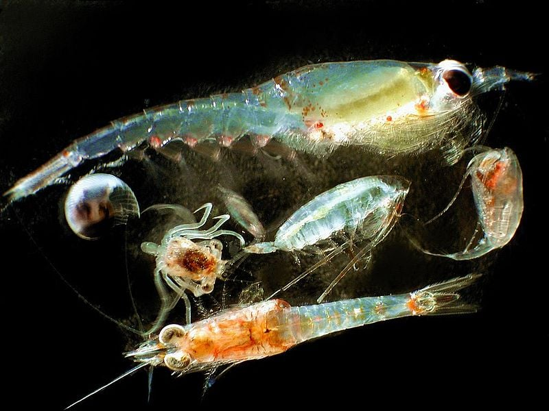

Jusqu’à présent, nous avions utilisé ces deux tableaux séparément. Notre objectif ici est de les analyser ensemble. Nous allons commencer par considérer ces deux tableaux comme quantitatifs. Dans ce cas, l’AFM réalisera deux ACP, une par tableau. Ensuite, elle pondérera les données de chacun en fonction de la part de variance sur le premier axe respectif. Pour finir, elle réalisera une ACP globale avec toutes les données qui conservera la structure de chacun des deux tableaux initiaux grâce à la pondération appliquée en interne.

Les données environnementales dans marphy étant mesurées dans des unités différentes, nous les standardiserons. Concernant le plancton dans marbio, nous allons pondérer les espèces rares par rapport aux espèces abondantes en transformant log(x+1) les abondances observées avec la fonction log1p(). Enfin, nous rajouterons les différentes masses d’eaux identifiées par ailleurs (voir l’aide ?pastecs::marphy) dans marzones que nous utiliserons comme troisième tableau de variables supplémentaires (un tableau que nous n’utilisons pas dans l’analyse, mais que nous représenterons dans les graphiques afin d’aider à leur interprétation). Voici donc la constitution d’un gros tableau qui reprend toutes les données dans la variable mar :

```r
marzones <- factor(c(
  rep("périphérique", 16),
  rep("divergente1", 8),
  rep("convergente", 5),
  rep("frontale", 11),
  rep("divergente2", 5),
  rep("centrale", 23)),
  levels = c("périphérique", "divergente1", "convergente",
    "frontale", "divergente2", "centrale"))

data("marphy", package = "pastecs")
data("marbio", package = "pastecs")
mar <- bind_cols(marphy, log1p(marbio)) %>% mutate(., Zone = marzones)
```

Ce tableau n’a aucune valeur manquante et il contient 29 variables :

```r
names(mar)
```

```
##  [1] "Temperature"            "Salinity"               "Fluorescence"
##  [4] "Density"                "Acartia"                "AdultsOfCalanus"
##  [7] "Copepodits1"            "Copepodits2"            "Copepodits3"
## [10] "Copepodits4"            "Copepodits5"            "ClausocalanusA"
## [13] "ClausocalanusB"         "ClausocalanusC"         "AdultsOfCentropages"
## [16] "JuvenilesOfCentropages" "Nauplii"                "Oithona"
## [19] "Acanthaires"            "Cladocerans"            "EchinodermsLarvae"
## [22] "DecapodsLarvae"         "GasteropodsLarvae"      "EggsOfCrustaceans"
## [25] "Ostracods"              "Pteropods"              "Siphonophores"
## [28] "BellsOfCalycophores"    "Zone"
```

Il y a trois groupes distincts :

- les 4 premières colonnes comme variables quantitatives continues pour l’**environnement**,
- les 24 colonnes suivantes comme quantitatives pour le **plancton**,
- la dernière colonne qui caractérise les masses d’eaux (**zone**) comme variable qualitative supplémentaire.

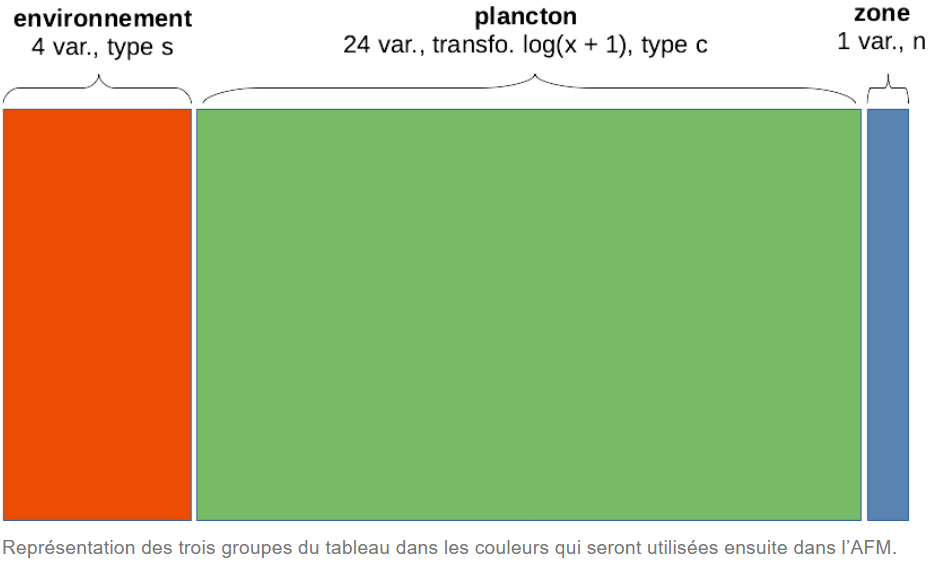

Avant de pouvoir réaliser notre AFM, nous devons comprendre comment écrire la formule qui va décrire nos données. Pour chaque groupe, nous ajouterons un terme à la formule qui contient trois composantes :

1. Le nombre `n` de colonnes constituant le groupe (les colonnes du tableau composite sont comptées de gauche à droite),
2. Le `type` de variable considérée. Quatre types sont possibles. Les variables continues à standardiser avant d’être utilisées dans une ACP sont de type **std**. Les variables quantitatives également à utiliser selon l’ACP, mais sans standardisation sont de type **num**. Les données qualitatives assimilables à un tableau de contingence à double entrée (données de fréquences d’observations, dénombrements, etc.) sont de type **cnt** et seront traitées comme une AFC, et enfin, les variables qualitatives classiques sont de type **fct** et seront traitées comme des variables qualitatives dans l’analyse factorielle multiple AFM.
3. Le `nom` que l’on veut donner à chaque groupe de variables pour l’identifier dans l’analyse.

Un groupe est décrit dans la formule comme `n * type %as% nom` (donc avec les opérateurs `*` et `%as%`). Chaque groupe inclus dans l’analyse est précédé d’un signe plus `+` (le premier plus peut être omis de la formule). Les groupes supplémentaires (à soustraire à l’analyse) sont précédés d’un signe moins `-`. Et enfin, tous les groupes sont décrits à la droite de la formule, donc, après le `~`.

Dans notre cas concret ici, cela donne :

```r
~ 4*std %as% environnement + 24*num %as% plancton - 1*fct %as% zone
```

L’analyse se fait en appelant `mfa(data = ...., formula)`. Nous assignons le résultat du calcul à `mar_mfa` :

```r
mar_mfa <- mfa(data = mar,
  ~ 4*std %as% environment + 24*num %as% plancton - 1*fct %as% zone)
```

```r
library(FactoMineR)
mar_MFA = MFA(base = mar, group = c(4,24,1), type = c("s","c","n"),
      name.group = c("Environement","Plancton","Zone"), graph = F)
#summary(mar_MFA)
```

```r
library("factoextra")
eig.val <- get_eigenvalue(mar_MFA)
head(eig.val)
```

```
##       eigenvalue variance.percent cumulative.variance.percent
## Dim.1  2.7054365        30.122224                    30.12222
## Dim.2  2.0005451        22.273991                    52.39621
## Dim.3  1.0823556        12.050905                    64.44712
## Dim.4  1.0623631        11.828309                    76.27543
## Dim.5  1.0235682        11.396369                    87.67180
## Dim.6  0.2614635         2.911124                    90.58292
```

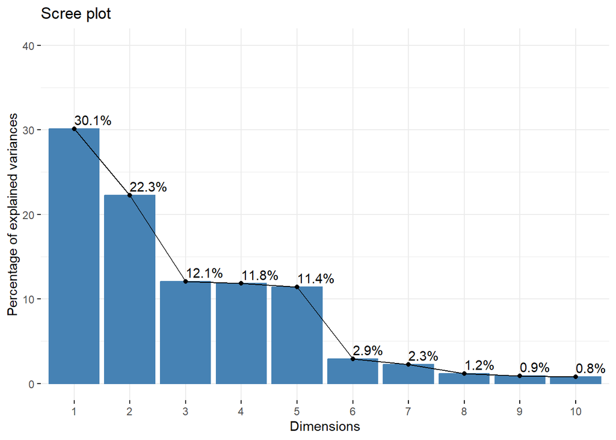

```r
fviz_screeplot(mar_MFA, addlabels = TRUE,ylim = c(0, 40))
```

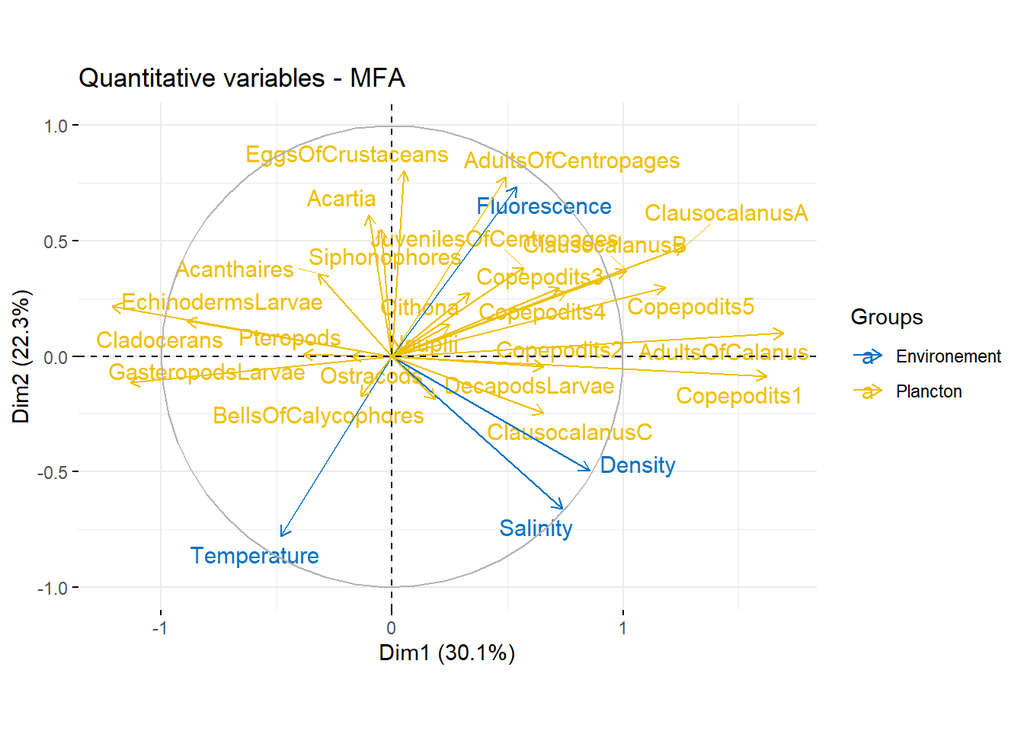

```r
fviz_mfa_var(mar_MFA, "quanti.var", palette = "jco",
             col.var.sup = "violet", repel = TRUE)
```

L’AFM est en fait un compromis réalisé entre des analyses indépendantes faites sur chaque groupe. Le graphique suivant montre comment ce compromis a été construit :

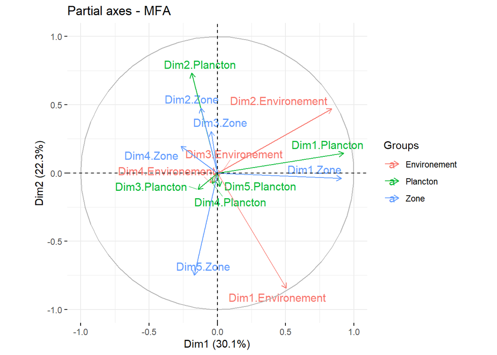

```r
fviz_mfa_axes (mar_MFA,repel = TRUE)
```

Tout comme pour l’ACP, nous pouvons maintenant interpréter le graphique dans l’espace des individus, normalement avec `chart$scores()`.

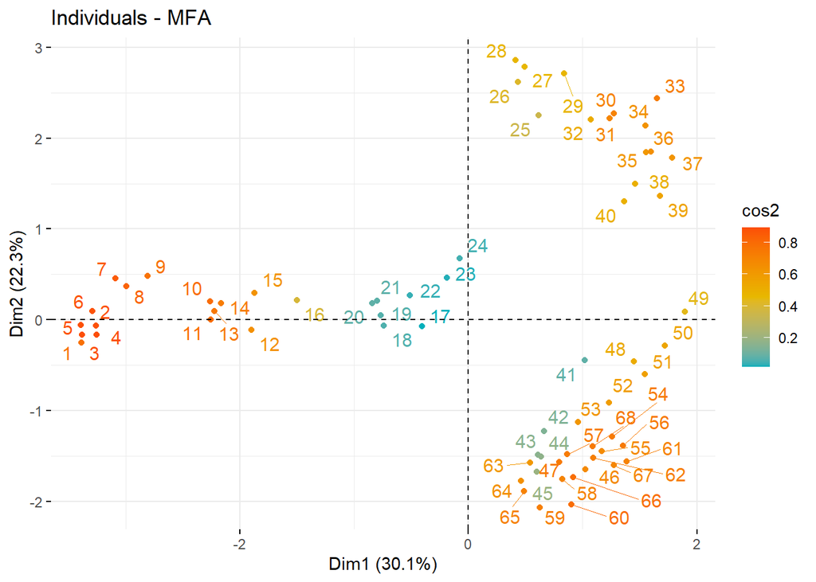

```r
fviz_mfa_ind(mar_MFA, col.ind = "cos2",
             gradient.cols = c("#00AFBB", "#E7B800", "#FC4E07"),
             repel = TRUE)
```

Cependant, nous pouvons aussi profiter de la variable supplémentaire zone pour colorer les points en fonction des masses d’eaux et représenter des ellipses pour chaque masse d’eau sur le graphique. La variante avec ces ellipses se réalise avec `chart$ellipses()` et il est plus clair dans pareil cas.

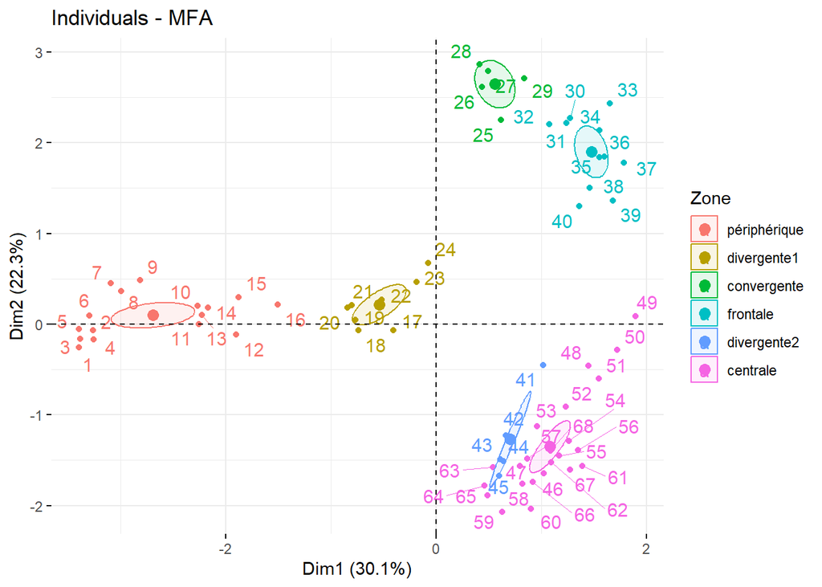

```r
fviz_mfa_ind(mar_MFA,
             habillage = "Zone", # color by groups
             #palette = c("#00AFBB", "#E7B800", "#FC4E07"),
             addEllipses = TRUE, ellipse.type = "confidence",
             repel = TRUE
             )
```

Notez qu’on a une progression le long du transect de la gauche (Nice) vers le centre, puis vers le haut à droite (le front) et puis vers le bas à droite (Calvi).

Si on interprète ce graphique des individus en fonction de l’orientation donnée sur base des variables, on peut dire que :

- Nice (zone périphérique) s’individualise très fort du reste, et c’est le plancton qui explique essentiellement cette différence avec les groupes identifiés tirant vers la gauche (GasteropodsLarvae, EchinodermLarvae, Cladocerans et Pteropods). Nice est aussi à une température et fluorescence moyenne.
- Toutes les autres zones sont caractérisées par une communauté planctonique différente de Nice, mais homogène, avec la zone divergente1 qui est logiquement intermédiaire (zone de mélange des masses d’eaux périphérique et frontale).
- La zone frontale est caractérisée par la température la plus basse et la fluorescence la plus élevée alors que la salinité est moyenne. C’est logique : on a une remontée d’eaux froides des profondeurs riches en nutriments que le phytoplancton utilise (fluorescence élevée signifie phytoplancton élevé).
- La zone centrale en Corse à Calvi est caractérisée par la salinité la plus élevée, une température élevée et une fluorescence basse, caractéristiques d’une zone oligotrophe. Comme nous l’avons déjà noté, la communauté planctonique est similaire à ce qu’on rencontre au large au milieu du transect, et elle tranche sensiblement avec celle rencontrée du côté niçois.

Revenons sur la façon dans l’AFM est construite (le fameux “compromis”), et son interprétation par rapport aux masses d’eaux. Le graphique suivant montre les relations entre les groupes.

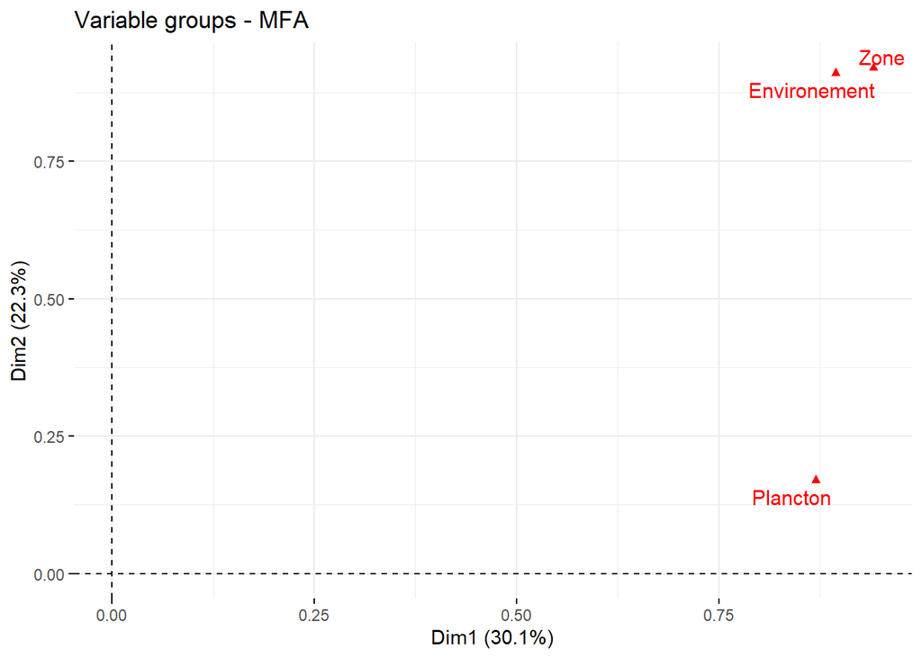

```r
fviz_mfa_var(mar_MFA, "group", repel = T)
```

Le graphique représente les groupes proches des axes dont ils sont responsables dans la structure générale de l’AFM. Nous voyons ici plancton proche de l’axe 1. Part contre, environnement est bien représenté (car il est loin du centre), mais est entre l’axe 1 et l’axes 2. Nous avons déjà noté cela précédemment.

La variable supplémentaire zone est aussi représentée à proximité de la structure qui lui correspond le mieux. Nous voyons que zone est plus proche d’environnement, ce qui signifie que les masses d’eau sont plutôt structurées en rapport avec les variables environnementales qu’en rapport avec les communautés planctoniques.

# AFM avec données mixtes

Jusqu’ici, nous avons réalisé une AFM avec uniquement des données quantitatives, mais l’AFM peut aussi traiter des données qualitatives, sous forme de tableaux de contingence à double entrée, ou sous forme de variables facteurs. Nous allons tester cette variante sans sortir de notre exemple du plancton méditerranéen. En effet, le tableau plancton peut aussi être considéré comme un tableau de contingence à double entrée. Il nous suffit de changer le type de ***cnum** à **cnt** (pour l’analyse des fréquences) dans la formule pour traiter à présent le plancton sous la forme d’une AFC dans `mar_mfa2`:

```r
library(FactoMineR)
mar_mfa2 = MFA(base = mar, group = c(4,24,1), type = c("s","f","n"),
      name.group = c("Environement","Plancton","Zone"), graph = F)
```

Rappelons-nous que l’AFC se ramène à une étape de son analyse à une ACP. C’est comme cela qu’il est possible de l’introduire dans l’AFM : à partir de l’étape ACP, les pondérations sont calculées et ajustées, et ensuite, une ACP globale est réalisée en la mélangeant avec les autres ACP.

Au lieu d’imprimer tout à l’aide de summary(), si nous souhaitons seulement les premières valeurs propres, nous pouvons aussi les extraire de l’objet comme ceci :

```r
library("factoextra")
eig.val2 <- get_eigenvalue(mar_mfa2)
head(eig.val2)
```

```
##       eigenvalue variance.percent cumulative.variance.percent
## Dim.1  2.7146225        30.933281                    30.93328
## Dim.2  1.8841070        21.469509                    52.40279
## Dim.3  1.0715478        12.210349                    64.61314
## Dim.4  1.0489785        11.953171                    76.56631
## Dim.5  1.0295240        11.731486                    88.29780
## Dim.6  0.2237987         2.550199                    90.84799
```

Ici, les deux premiers axes comptent pour 52,4% de variance cumulée. Le graphe des éboulis confirme que deux axes suffisent :

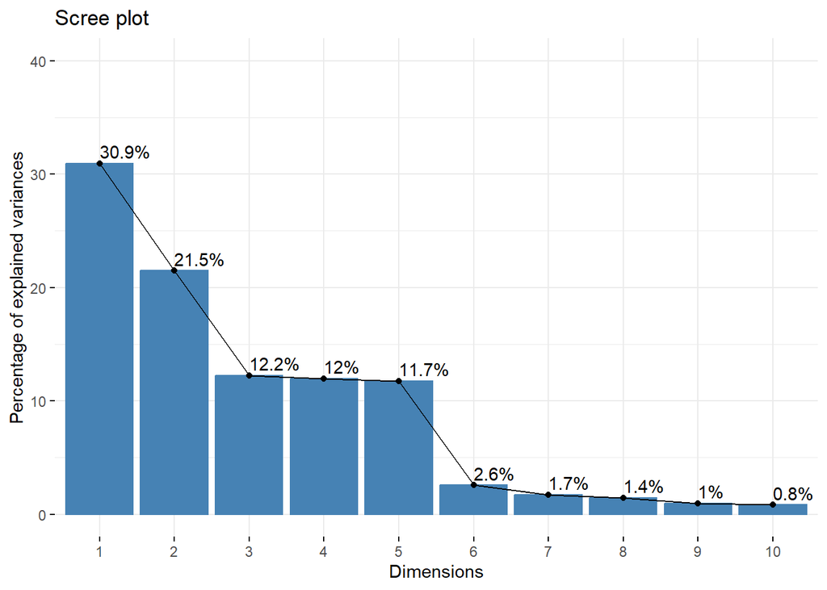

```r
fviz_screeplot(mar_mfa2, addlabels = TRUE,ylim = c(0, 40))
```

Le graphique des variables ne montre plus que celles relatives à l’ACP, donc seulement le groupe environnement. Les conclusions à leur sujet sont les mêmes, mais attention, le premier plan de la nouvelle AFM se présente en miroir haut-bas par rapport à notre première analyse.

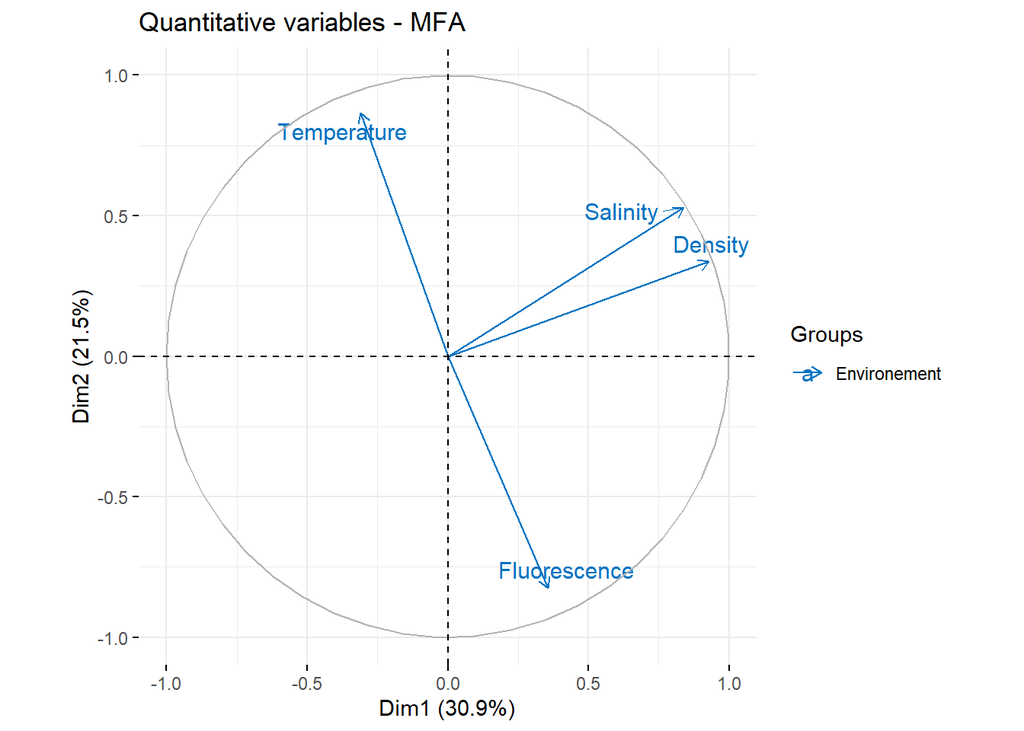

```r
fviz_mfa_var(mar_mfa2, "quanti.var", palette = "jco", repel = TRUE)
```

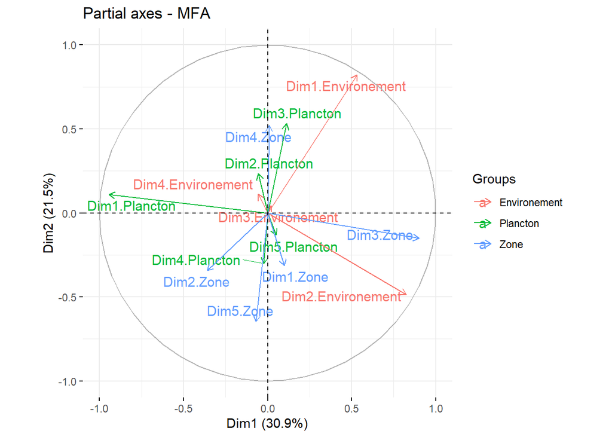

```r
fviz_mfa_axes (mar_mfa2,repel = TRUE)
```

Les conclusions sont similaires sur les axes. Voyons maintenant l’espace des individus, toujours avec les couleurs et les ellipses par zones :

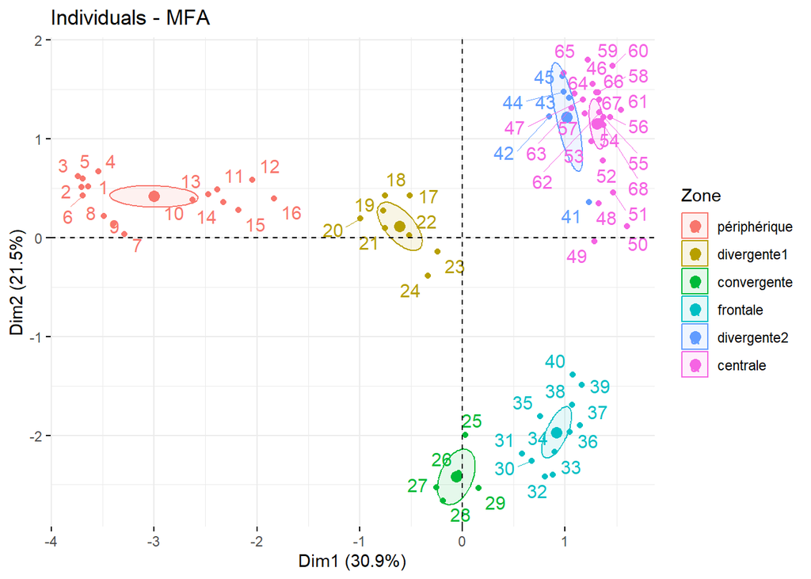

```r
fviz_mfa_ind(mar_mfa2,
             habillage = "Zone", # color by groups
             #palette = c("#00AFBB", "#E7B800", "#FC4E07"),
             addEllipses = TRUE, ellipse.type = "confidence",
             repel = TRUE
             )
```

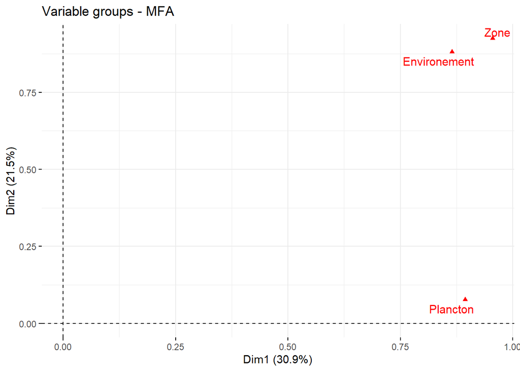

```r
fviz_mfa_var(mar_mfa2, "group", repel = T)
```